# Soil respiration. Banana project

Raquel Correa

2023-10-24

### Evolution of soil respiration over time

One way to measure the microbial community of a soil is respiration. Check how much CO2 is released from it.

1. Basal respiration: The falcon tubes (50 ml), with the original soil samples, were placed in jars with hermetic closure. The evaluation of respiration (CO2 production) was carried out by titration of the sodium hydroxide (0.5 M) with hydrochloric acid (0.5 M) once the sample has been incubated for 7 days at 25ºC. Basal respiration provides an indication of the microbial activity supported by the organic matter present in the soil. It reflects the metabolism of microorganisms utilizing the existing organic carbon pool.
2. Induced respiration: Induced respiration was carried out once basal respiration had been evaluated (that is, on the same samples). A solution is added of 20% sterile glucose (0.5 ml/sample). Subsequently, the samples were incubated at 25ºC for 2.5 days and the sodium hydroxide (0.5 M) was titrated with hydrochloric acid (0.5 M).Induced respiration provides insights into the potential microbial activity that can be activated in response to changes in the availability of easily degradable carbon sources. It helps researchers understand how the microbial community responds to specific inputs or disturbances.

The results of basal respiration and induced respiration in the same soil sample can be different. These two measurements capture different aspects of microbial activity and provide complementary information about the soil’s response to different conditions.

-Basal Respiration:

Reflects the baseline or inherent microbial activity in the soil under normal, undisturbed conditions. Represents the ongoing metabolism of microorganisms utilizing the existing organic carbon pool in the soil. Typically measured without the addition of external carbon sources or specific disturbances.

-Induced Respiration:

Reflects the additional microbial activity that can be stimulated by external factors or disturbances. Involves the addition of a substrate (e.g., glucose) or other stimuli to induce a response from the microbial community. Provides insights into the potential for increased microbial activity when additional carbon sources are made available

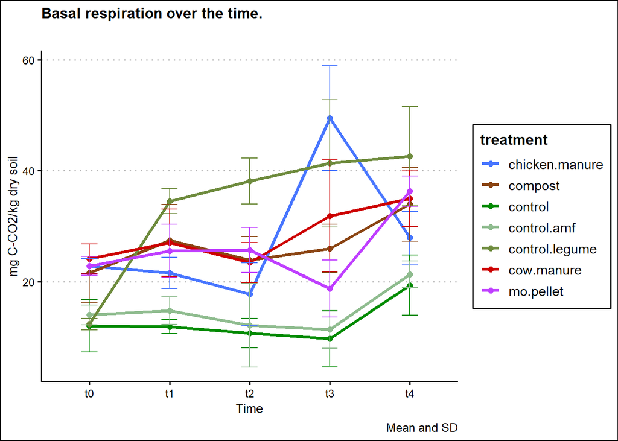

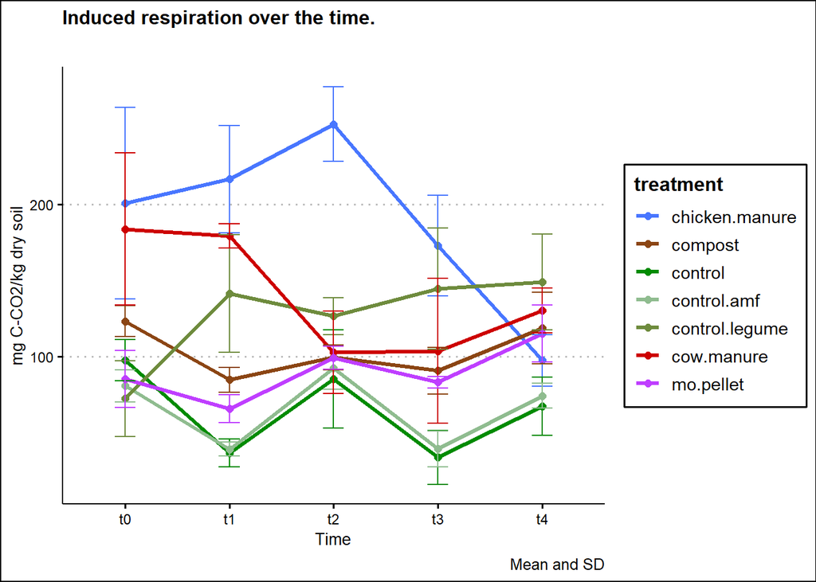

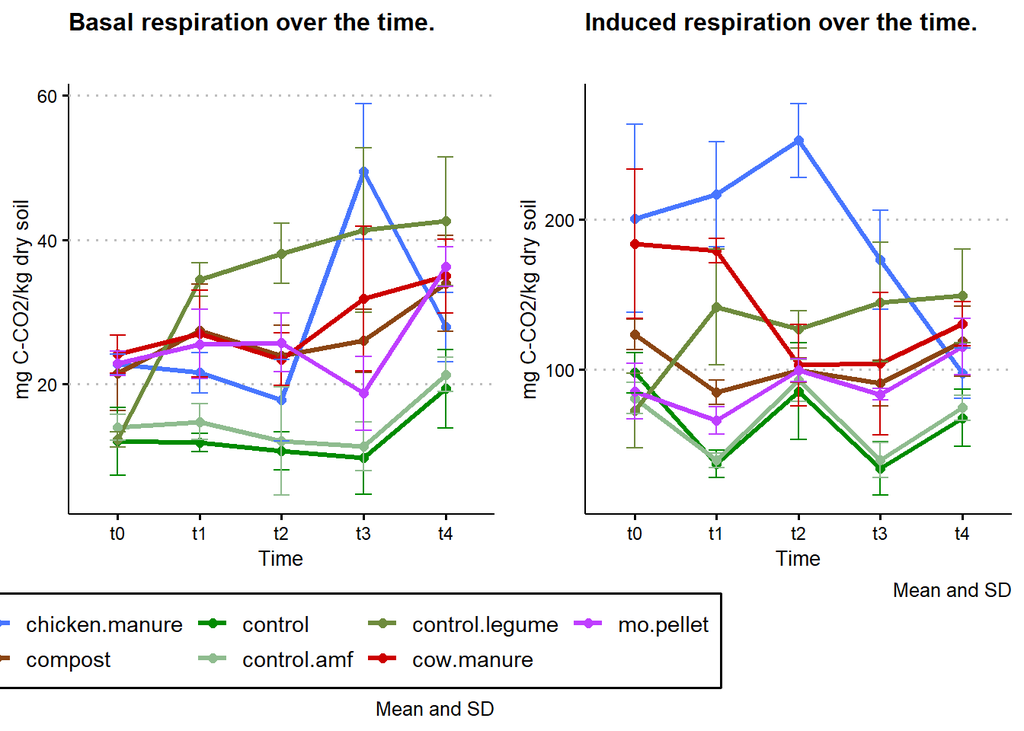

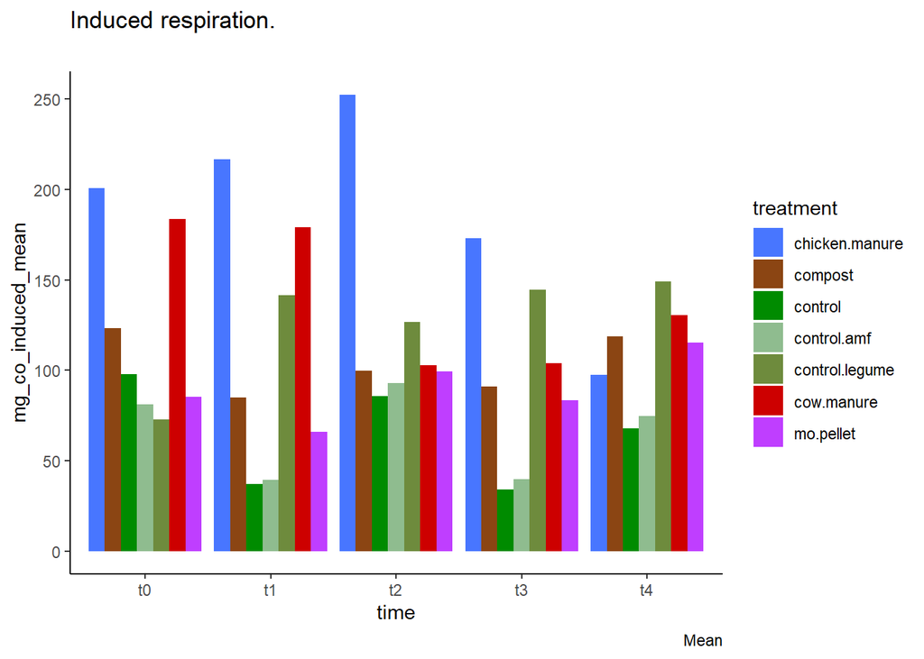

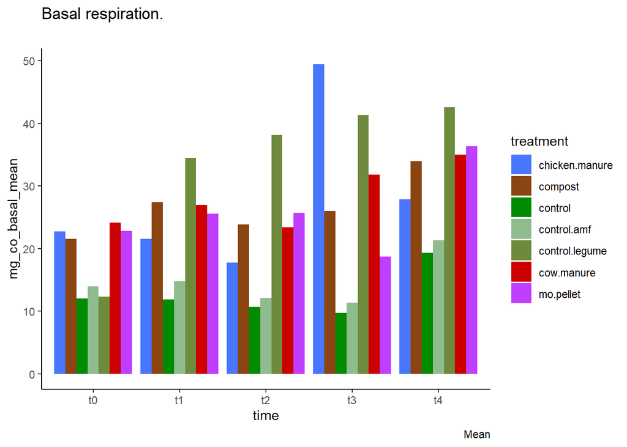

### Differences of respiration between treatments at the start of the experiment (t0)

```
##
##  Shapiro-Wilk normality test
##
## data:  respirationt0$mg_co_basal
## W = 0.94562, p-value = 0.2808
```

```
## Levene's Test for Homogeneity of Variance (center = median)
##       Df F value Pr(>F)
## group  6  0.6974 0.6563
##       14
```

```
##        treatment mg_co_basal groups
## 1     cow.manure    24.10956      a
## 2      mo.pellet    22.81325      a
## 3 chicken.manure    22.74077      a
## 4        compost    21.51193     ab
## 5    control.amf    13.95694     bc
## 6 control.legume    12.30978      c
## 7        control    12.02287      c
```

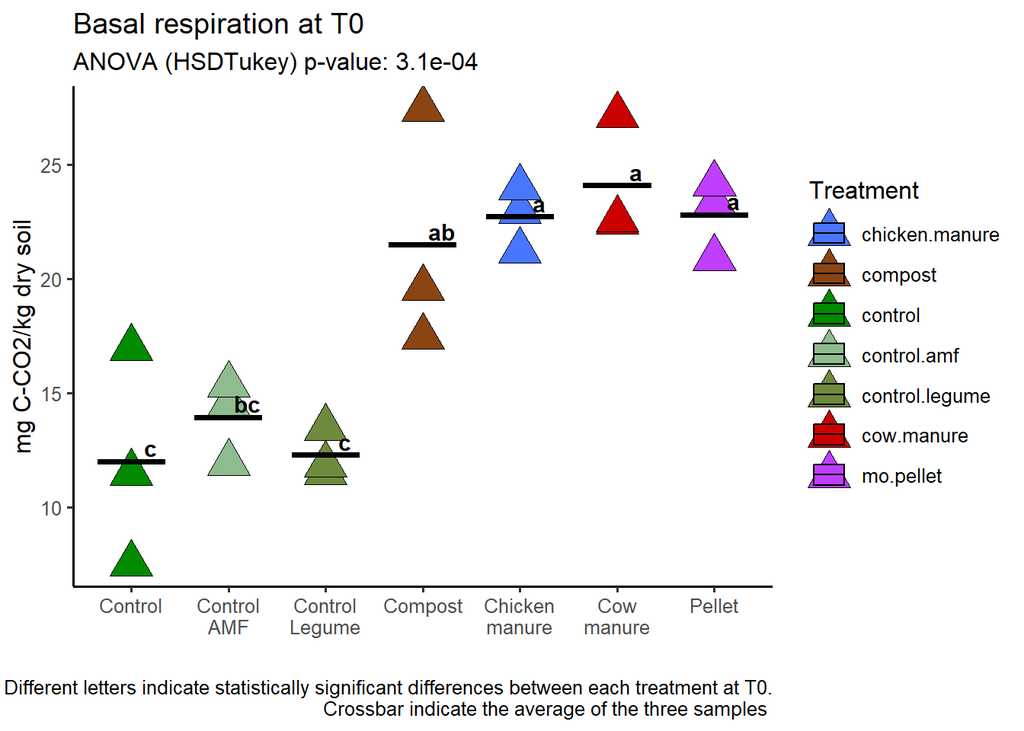

```
##
##  Shapiro-Wilk normality test
##
## data:  respirationt0$mg_co_induced
## W = 0.85139, p-value = 0.00449
```

```
## # A tibble: 7 x 4
##   treatment      variable      statistic     p
##   <chr>          <chr>             <dbl> <dbl>
## 1 chicken.manure mg_co_induced     0.934 0.313
## 2 compost        mg_co_induced     0.952 0.563
## 3 control        mg_co_induced     0.966 0.791
## 4 control.amf    mg_co_induced     0.943 0.428
## 5 control.legume mg_co_induced     0.968 0.833
## 6 cow.manure     mg_co_induced     0.979 0.961
## 7 mo.pellet      mg_co_induced     0.981 0.974
```

```
## Levene's Test for Homogeneity of Variance (center = median)
##       Df F value Pr(>F)
## group  6  0.7575 0.6145
##       14
```

```
##        treatment mg_co_induced groups
## 1 chicken.manure     200.71736      a
## 2     cow.manure     183.79782      a
## 3        compost     123.42938     ab
## 4        control      97.87817      b
## 5      mo.pellet      85.45598      b
## 6    control.amf      80.93666      b
## 7 control.legume      72.63334      b
```

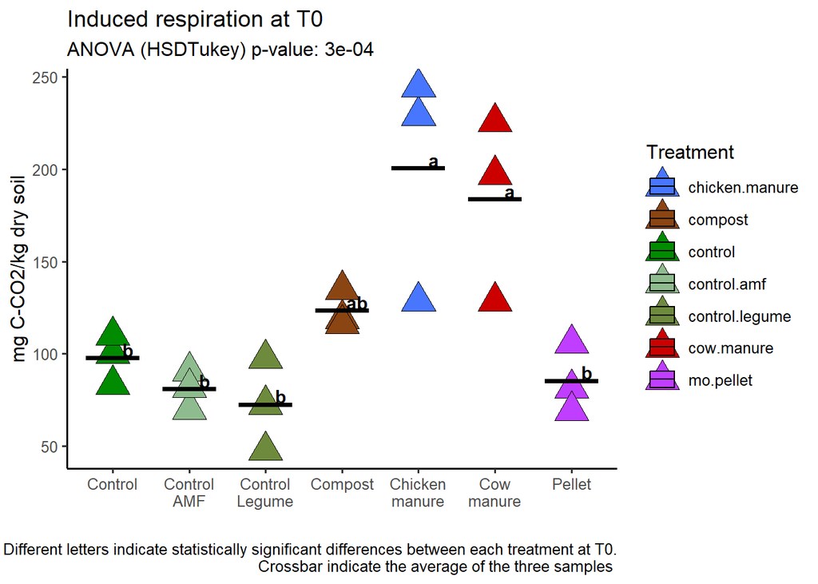

### Differences of respiration between treatments at T1

```
##
##  Shapiro-Wilk normality test
##
## data:  respirationt1$mg_co_basal
## W = 0.94273, p-value = 0.2467
```

[output not shown]

```
##        treatment mg_co_basal groups
## 1 control.legume    34.48413      a
## 2        compost    27.41494     ab
## 3     cow.manure    26.96309     ab
## 4      mo.pellet    25.53235    abc
## 5 chicken.manure    21.53318    bcd
## 6    control.amf    14.74839     cd
## 7        control    11.87130      d
```

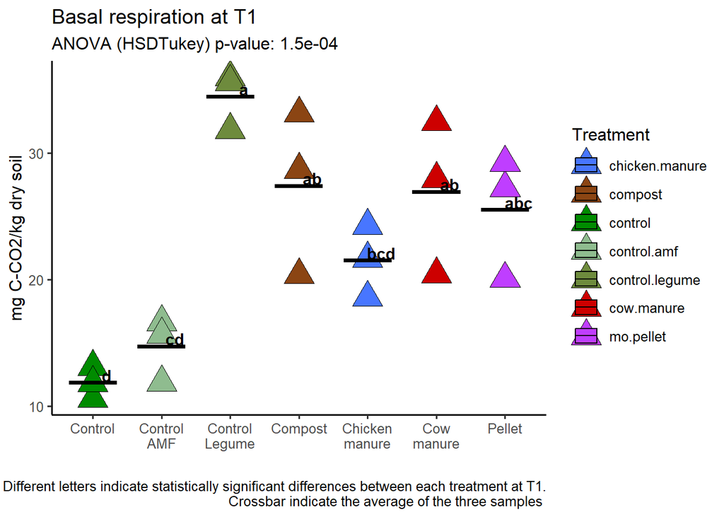

```
##
##  Shapiro-Wilk normality test
##
## data:  respirationt1$mg_co_induced
## W = 0.88835, p-value = 0.02093
```

[output not shown]

```
## Levene's Test for Homogeneity of Variance (center = median)
##       Df F value Pr(>F)
## group  6  0.7637 0.6102
##       14
```

```
##        treatment mg_co_induced groups
## 1 chicken.manure     216.64329      a
## 2     cow.manure     179.26120     ab
## 3 control.legume     141.55713      b
## 4        compost      85.00410      c
## 5      mo.pellet      65.82853      c
## 6    control.amf      39.49295      c
## 7        control      36.93117      c
```

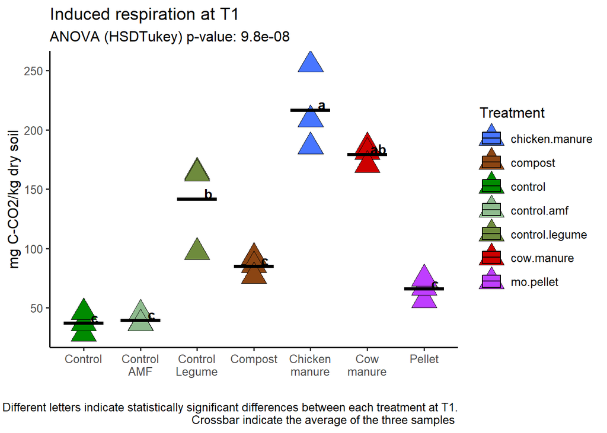

### Differences of respiration between treatments at T2

```
##
##  Shapiro-Wilk normality test
##
## data:  respirationt2$mg_co_basal
## W = 0.98704, p-value = 0.9898
```

[output not shown]

```
##        treatment mg_co_basal groups
## 1 control.legume    38.11201      a
## 2      mo.pellet    25.70396     ab
## 3        compost    23.86362     bc
## 4     cow.manure    23.42304     bc
## 5 chicken.manure    17.71893     bc
## 6    control.amf    12.09018     bc
## 7        control    10.69681      c
```

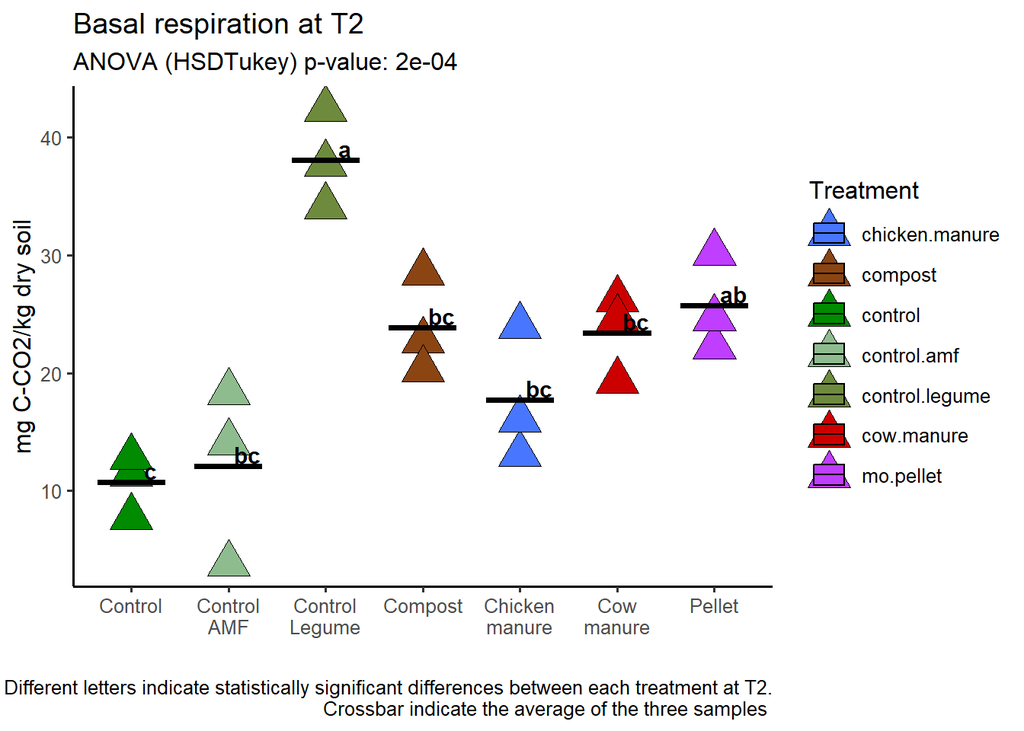

```
##
##  Shapiro-Wilk normality test
##
## data:  respirationt2$mg_co_induced
## W = 0.75004, p-value = 0.0001241
```

[output not shown]

```
## Levene's Test for Homogeneity of Variance (center = median)
##       Df F value Pr(>F)
## group  6  0.4707 0.8189
##       14
```

```
##        treatment mg_co_induced groups
## 1 chicken.manure     252.55188      a
## 2 control.legume     126.70056      b
## 3     cow.manure     102.93817      b
## 4        compost      99.71467      b
## 5      mo.pellet      99.40249      b
## 6    control.amf      92.81855      b
## 7        control      85.57502      b
```

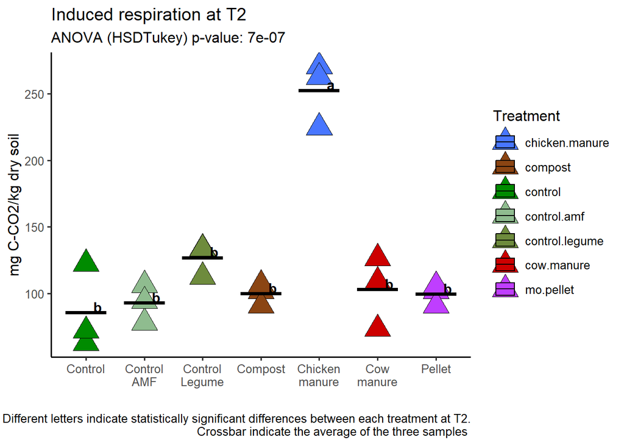

### Differences of respiration between treatments at T3

```
##
##  Shapiro-Wilk normality test
##
## data:  respirationt3$mg_co_basal
## W = 0.94881, p-value = 0.3234
```

[output not shown]

```
##        treatment mg_co_basal groups
## 1 chicken.manure   49.458905      a
## 2 control.legume   41.348068     ab
## 3     cow.manure   31.824497    abc
## 4        compost   25.963813     bc
## 5      mo.pellet   18.708108      c
## 6    control.amf   11.311030      c
## 7        control    9.727477      c
```

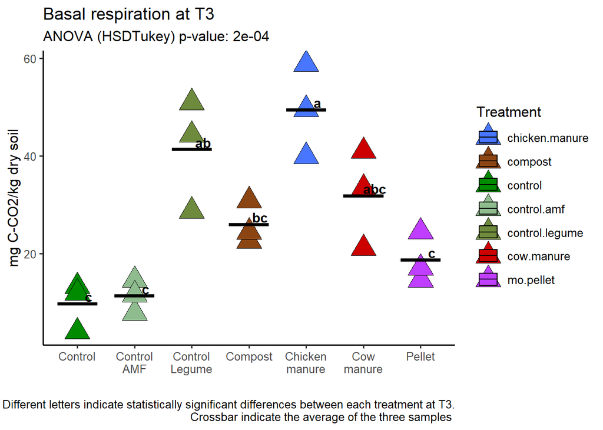

```
##
##  Shapiro-Wilk normality test
##
## data:  respirationt3$mg_co_induced
## W = 0.95465, p-value = 0.4154
```

[output not shown]

```
## Levene's Test for Homogeneity of Variance (center = median)
##       Df F value Pr(>F)
## group  6  0.9017 0.5206
##       14
```

```
##        treatment mg_co_induced groups
## 1 chicken.manure     173.10617      a
## 2 control.legume     144.71824     ab
## 3     cow.manure     103.87527    abc
## 4        compost      90.87335    abc
## 5      mo.pellet      83.39908     bc
## 6    control.amf      39.58860      c
## 7        control      34.04617      c
```

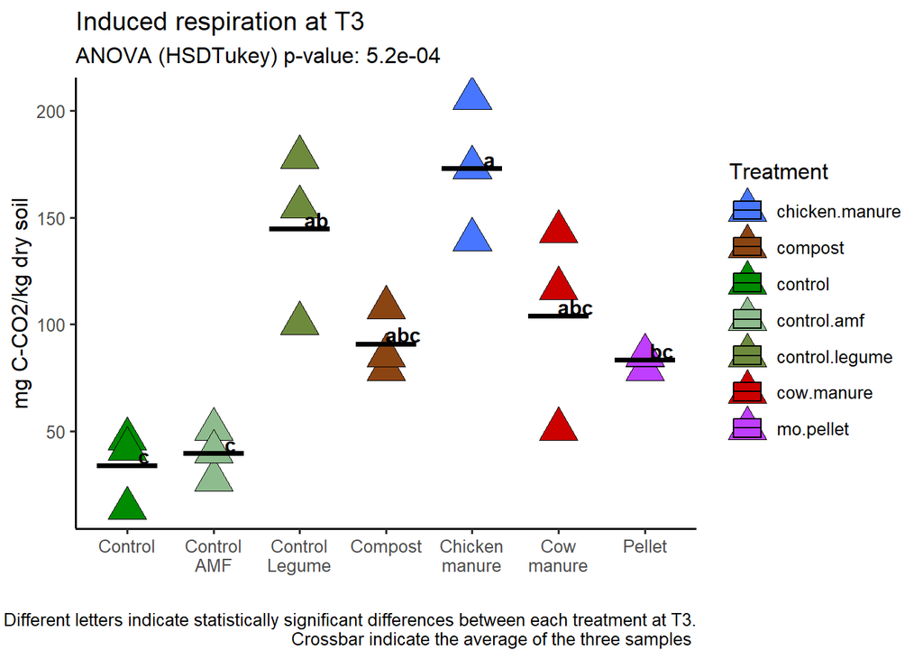

### Differences of respiration between treatments at T4

```
##
##  Shapiro-Wilk normality test
##
## data:  respirationt4$mg_co_basal
## W = 0.97062, p-value = 0.7467
```

[output not shown]

```
##        treatment mg_co_basal groups
## 1 control.legume    42.57792      a
## 2      mo.pellet    36.30094     ab
## 3     cow.manure    34.97345    abc
## 4        compost    33.94118    abc
## 5 chicken.manure    27.88803    abc
## 6    control.amf    21.29169     bc
## 7        control    19.32903      c
```

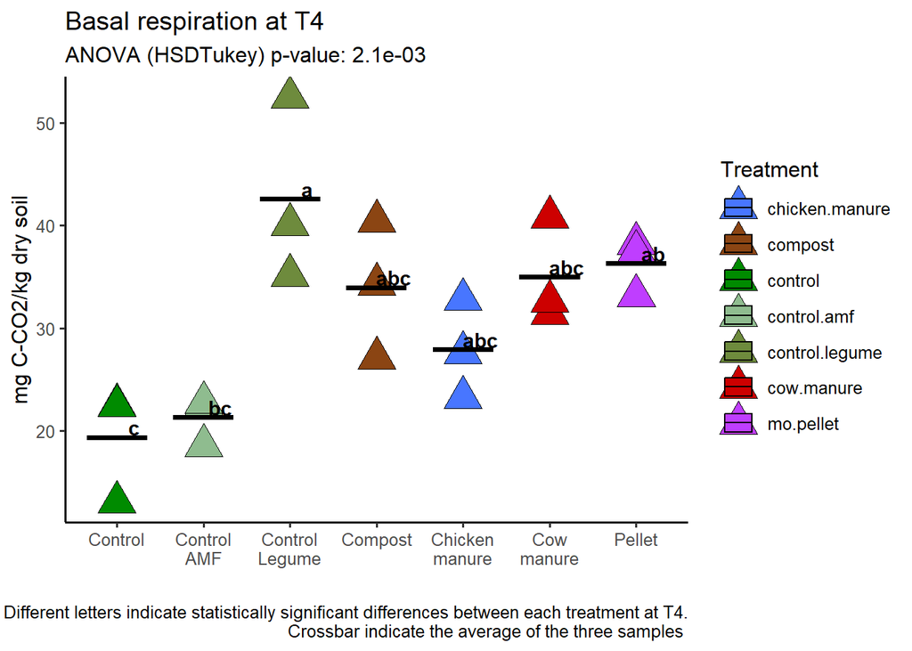

```
##
##  Shapiro-Wilk normality test
##
## data:  respirationt4$mg_co_induced
## W = 0.96822, p-value = 0.6934
```

[output not shown]

```
## Levene's Test for Homogeneity of Variance (center = median)
##       Df F value Pr(>F)
## group  6  0.3395 0.9045
##       14
```

```
##        treatment mg_co_induced groups
## 1 control.legume     149.02271      a
## 2     cow.manure     130.36820     ab
## 3        compost     118.79414    abc
## 4      mo.pellet     115.30364    abc
## 5 chicken.manure      97.60812    abc
## 6    control.amf      74.52093     bc
## 7        control      67.65161      c
```

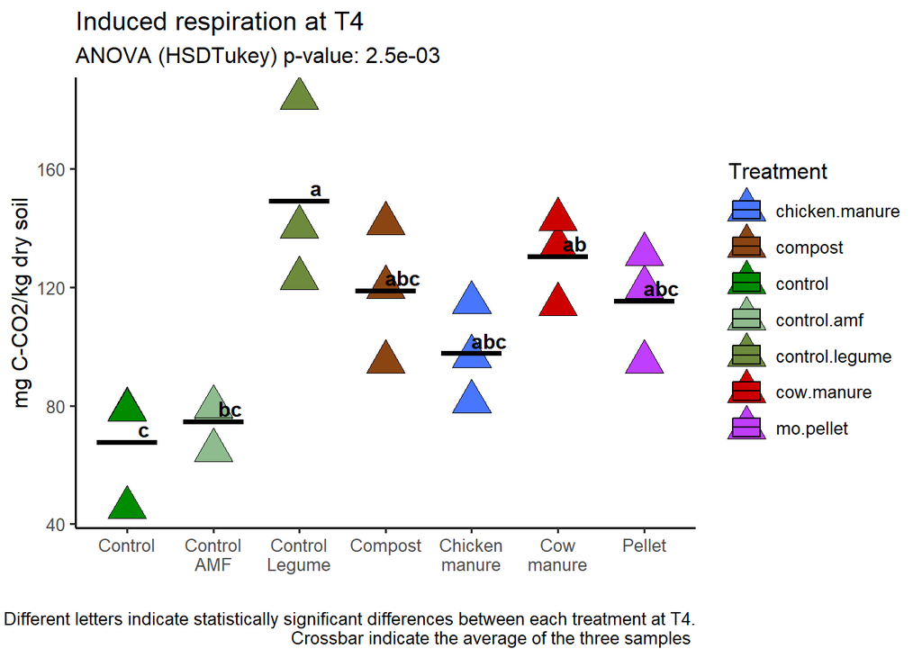

```
## adding dummy grobs
```

[figure not shown]

[figure not shown]

```
## adding dummy grobs
```

[figure not shown]

[figure not shown]

### How much has the respiration of each treatment varied from the beginning of the experiment to the end (T4 and tT0)?

Delta Variation (ΔBasal Respiration): It represents the change or difference in basal respiration values between two specific time points. Mathematically, it is often expressed as the subtraction of the basal respiration value at an earlier time point from the value at a later time point.

-Positive ΔBasal Respiration: Indicates an increase in basal respiration from the earlier time point to the later time point. This could be due to factors such as increased microbial activity, higher availability of organic matter, or changes in environmental conditions that favor microbial respiration.

-Negative ΔBasal Respiration: Indicates a decrease in basal respiration from the earlier time point to the later time point. This could be due to factors such as decreased microbial activity, depletion of organic matter, or changes in environmental conditions that suppress microbial respiration.

-Zero ΔBasal Respiration: Indicates no change in basal respiration between the two time points. The microbial activity and respiration rates remain constant over this period.

```
##
##  Shapiro-Wilk normality test
##
## data:  respirationt0t4$mg_co_basal
## W = 0.96091, p-value = 0.1592
```

```
## Levene's Test for Homogeneity of Variance (center = median)
##       Df F value Pr(>F)
## group 13  0.6088 0.8263
##       28
```

```
## boundary (singular) fit: see help('isSingular')
```

```
## Linear mixed model fit by REML. t-tests use Satterthwaite's method [
## lmerModLmerTest]
## Formula: mg_co_basal ~ time * treatment + (1 | treat.pot)
##    Data: respirationt0t4
##
## REML criterion at convergence: 179
##
## Scaled residuals:
##      Min       1Q   Median       3Q      Max
## -1.65393 -0.49907 -0.00287  0.32200  2.20837
##
## Random effects:
##  Groups    Name        Variance Std.Dev.
##  treat.pot (Intercept)  0.00    0.000
##  Residual              20.18    4.492
## Number of obs: 42, groups:  treat.pot, 21
##
## Fixed effects:
##                                 Estimate Std. Error        df t value Pr(>|t|)
## (Intercept)                     22.74077    2.59338  28.00000   8.769 1.61e-09
## timet4                           5.14727    3.66760  28.00000   1.403  0.17148
## treatmentcompost                -1.22883    3.66760  28.00000  -0.335  0.74008
## treatmentcontrol               -10.71789    3.66760  28.00000  -2.922  0.00680
## treatmentcontrol.amf            -8.78382    3.66760  28.00000  -2.395  0.02355
## treatmentcontrol.legume        -10.43099    3.66760  28.00000  -2.844  0.00823
## treatmentcow.manure              1.36880    3.66760  28.00000   0.373  0.71180
## treatmentmo.pellet               0.07248    3.66760  28.00000   0.020  0.98437
## timet4:treatmentcompost          7.28198    5.18676  28.00000   1.404  0.17133
## timet4:treatmentcontrol          2.15889    5.18676  28.00000   0.416  0.68041
## timet4:treatmentcontrol.amf      2.18748    5.18676  28.00000   0.422  0.67643
## timet4:treatmentcontrol.legume  25.12087    5.18676  28.00000   4.843 4.26e-05
## timet4:treatmentcow.manure       5.71661    5.18676  28.00000   1.102  0.27978
## timet4:treatmentmo.pellet        8.34042    5.18676  28.00000   1.608  0.11905
##
## (Intercept)                    ***
## timet4
## treatmentcompost
## treatmentcontrol               **
## treatmentcontrol.amf           *
## treatmentcontrol.legume        **
## treatmentcow.manure
## treatmentmo.pellet
## timet4:treatmentcompost
## timet4:treatmentcontrol
## timet4:treatmentcontrol.amf
## timet4:treatmentcontrol.legume ***
## timet4:treatmentcow.manure
## timet4:treatmentmo.pellet
## ---
## Signif. codes:  0 '***' 0.001 '**' 0.01 '*' 0.05 '.' 0.1 ' ' 1
```

```
##
## Correlation matrix not shown by default, as p = 14 > 12.
## Use print(x, correlation=TRUE)  or
##     vcov(x)        if you need it
```

```
## optimizer (nloptwrap) convergence code: 0 (OK)
## boundary (singular) fit: see help('isSingular')
```

```
## Type III Analysis of Variance Table with Satterthwaite's method
##                 Sum Sq Mean Sq NumDF DenDF F value    Pr(>F)
## time           1615.86 1615.86     1    28 80.0848 1.052e-09 ***
## treatment      1173.58  195.60     6    28  9.6941 8.536e-06 ***
## time:treatment  640.53  106.75     6    28  5.2910  0.000939 ***
## ---
## Signif. codes:  0 '***' 0.001 '**' 0.01 '*' 0.05 '.' 0.1 ' ' 1
```

```
## $emmeans
## treatment = chicken.manure:
##  time emmean   SE df lower.CL upper.CL
##  t0     22.7 2.59 28    17.43     28.1
##  t4     27.9 2.59 28    22.58     33.2
##
## treatment = compost:
##  time emmean   SE df lower.CL upper.CL
##  t0     21.5 2.59 28    16.20     26.8
##  t4     33.9 2.59 28    28.63     39.3
##
## treatment = control:
##  time emmean   SE df lower.CL upper.CL
##  t0     12.0 2.59 28     6.71     17.3
##  t4     19.3 2.59 28    14.02     24.6
##
## treatment = control.amf:
##  time emmean   SE df lower.CL upper.CL
##  t0     14.0 2.59 28     8.64     19.3
##  t4     21.3 2.59 28    15.98     26.6
##
## treatment = control.legume:
##  time emmean   SE df lower.CL upper.CL
##  t0     12.3 2.59 28     7.00     17.6
##  t4     42.6 2.59 28    37.27     47.9
##
## treatment = cow.manure:
##  time emmean   SE df lower.CL upper.CL
##  t0     24.1 2.59 28    18.80     29.4
##  t4     35.0 2.59 28    29.66     40.3
##
## treatment = mo.pellet:
##  time emmean   SE df lower.CL upper.CL
##  t0     22.8 2.59 28    17.50     28.1
##  t4     36.3 2.59 28    30.99     41.6
##
## Degrees-of-freedom method: kenward-roger
## Confidence level used: 0.95
##
## $contrasts
```

[output cut: 14 more lines]

```
##  t0 - t4     -7.33 3.67 14  -2.000  0.0653
##
## treatment = control.legume:
##  contrast estimate   SE df t.ratio p.value
##  t0 - t4    -30.27 3.67 14  -8.253  <.0001
##
## treatment = cow.manure:
##  contrast estimate   SE df t.ratio p.value
##  t0 - t4    -10.86 3.67 14  -2.962  0.0103
##
## treatment = mo.pellet:
##  contrast estimate   SE df t.ratio p.value
##  t0 - t4    -13.49 3.67 14  -3.678  0.0025
##
## Degrees-of-freedom method: kenward-roger
```

```
##  treatment      contrast estimate   SE df lower.CL upper.CL t.ratio p.value
##  chicken.manure t0 - t4     -5.15 3.67 14    -16.7    6.392  -1.403  0.1823
##  compost        t0 - t4    -12.43 3.67 14    -24.0   -0.890  -3.389  0.0103
##  control        t0 - t4     -7.31 3.67 14    -18.8    4.233  -1.992  0.0773
##  control.amf    t0 - t4     -7.33 3.67 14    -18.9    4.205  -2.000  0.0773
##  control.legume t0 - t4    -30.27 3.67 14    -41.8  -18.728  -8.253  <.0001
##  cow.manure     t0 - t4    -10.86 3.67 14    -22.4    0.676  -2.962  0.0180
##  mo.pellet      t0 - t4    -13.49 3.67 14    -25.0   -1.948  -3.678  0.0087
##
## Degrees-of-freedom method: kenward-roger
## Confidence level used: 0.95
## Conf-level adjustment: bonferroni method for 7 estimates
## P value adjustment: fdr method for 7 tests
```

```
##   contrast      treatment   estimate       SE df   t.ratio      p.value
## 1  t0 - t4 chicken.manure  -5.147268 3.667596 14 -1.403445 1.822742e-01
## 2  t0 - t4        compost -12.429252 3.667596 14 -3.388938 4.408853e-03
## 3  t0 - t4        control  -7.306160 3.667596 14 -1.992084 6.623627e-02
## 4  t0 - t4    control.amf  -7.334751 3.667596 14 -1.999880 6.530224e-02
## 5  t0 - t4 control.legume -30.268139 3.667596 14 -8.252856 9.515380e-07
## 6  t0 - t4     cow.manure -10.863882 3.667596 14 -2.962127 1.029573e-02
## 7  t0 - t4      mo.pellet -13.487691 3.667596 14 -3.677530 2.485503e-03
```

```
## # A tibble: 7 x 2
##   treatment      emmean
##   <fct>           <dbl>
## 1 chicken.manure   25.3
## 2 compost          27.7
## 3 control          15.7
## 4 control.amf      17.6
## 5 control.legume   27.4
## 6 cow.manure       29.5
## 7 mo.pellet        29.6
```

```
## NOTE: Results may be misleading due to involvement in interactions
```

```
##  treatment      emmean   SE df lower.CL upper.CL .group
##  mo.pellet        29.6 1.83 14     25.6     33.5  a
##  cow.manure       29.5 1.83 14     25.6     33.5  a
##  compost          27.7 1.83 14     23.8     31.7  a
##  control.legume   27.4 1.83 14     23.5     31.4  a
##  chicken.manure   25.3 1.83 14     21.4     29.2  ab
##  control.amf      17.6 1.83 14     13.7     21.6   bc
##  control          15.7 1.83 14     11.7     19.6    c
##
## Results are averaged over the levels of: time
## Degrees-of-freedom method: kenward-roger
## Confidence level used: 0.95
## P value adjustment: tukey method for comparing a family of 7 estimates
## significance level used: alpha = 0.05
## NOTE: If two or more means share the same grouping symbol,
##       then we cannot show them to be different.
##       But we also did not show them to be the same.
```

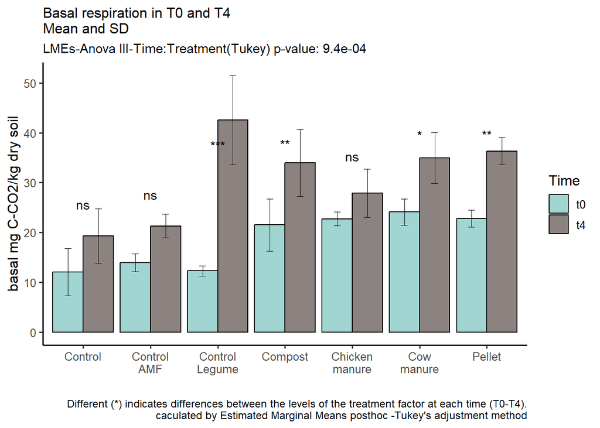

```
##         treatment       t4        t0      delta
## 1         control 13.03729 16.988825 -3.9515306
## 2         control 22.53004  7.545272 14.9847684
## 3         control 22.41976 11.534518 10.8852427
## 4     control.amf 22.56889 14.539219  8.0296759
## 5     control.amf 22.74795 15.373699  7.3742535
## 6     control.amf 18.55823 11.957908  6.6003234
## 7  chicken.manure 27.62652 22.976459  4.6500623
## 8  chicken.manure 23.23875 21.239773  1.9989741
## 9  chicken.manure 32.79883 24.006065  8.7927691
## 10     cow.manure 31.44147 22.518963  8.9225072
## 11     cow.manure 32.65076 27.173913  5.4768448
## 12     cow.manure 40.82811 22.635815 18.1922946
## 13      mo.pellet 38.26531 20.917261 17.3480455
## 14      mo.pellet 33.17497 23.345347  9.8296199
## 15      mo.pellet 37.46254 24.177129 13.2854082
## 16        compost 27.09360 27.439024 -0.3454283
## 17        compost 34.27556 19.614253 14.6613055
## 18        compost 40.45440 17.482517 22.9718794
## 19 control.legume 52.49761 13.505402 38.9922116
## 20 control.legume 40.08746 11.545567 28.5418971
## 21 control.legume 35.14867 11.878366 23.2703093
```

```
## $emmeans
##  treatment      emmean   SE df lower.CL upper.CL
##  chicken.manure   5.15 4.21 14    -3.89     14.2
##  compost         12.43 4.21 14     3.40     21.5
##  control          7.31 4.21 14    -1.73     16.3
##  control.amf      7.33 4.21 14    -1.70     16.4
##  control.legume  30.27 4.21 14    21.23     39.3
##  cow.manure      10.86 4.21 14     1.83     19.9
##  mo.pellet       13.49 4.21 14     4.45     22.5
##
## Confidence level used: 0.95
##
## $contrasts
##  contrast                        estimate   SE df t.ratio p.value
##  chicken.manure - compost         -7.2820 5.96 14  -1.222  0.8742
##  chicken.manure - control         -2.1589 5.96 14  -0.362  0.9997
##  chicken.manure - control.amf     -2.1875 5.96 14  -0.367  0.9997
##  chicken.manure - control.legume -25.1209 5.96 14  -4.217  0.0117
##  chicken.manure - cow.manure      -5.7166 5.96 14  -0.960  0.9550
##  chicken.manure - mo.pellet       -8.3404 5.96 14  -1.400  0.7933
##  compost - control                 5.1231 5.96 14   0.860  0.9731
##  compost - control.amf             5.0945 5.96 14   0.855  0.9738
##  compost - control.legume        -17.8389 5.96 14  -2.995  0.1039
##  compost - cow.manure              1.5654 5.96 14   0.263  1.0000
##  compost - mo.pellet              -1.0584 5.96 14  -0.178  1.0000
##  control - control.amf            -0.0286 5.96 14  -0.005  1.0000
##  control - control.legume        -22.9620 5.96 14  -3.855  0.0226
##  control - cow.manure             -3.5577 5.96 14  -0.597  0.9959
##  control - mo.pellet              -6.1815 5.96 14  -1.038  0.9361
##  control.amf - control.legume    -22.9334 5.96 14  -3.850  0.0228
##  control.amf - cow.manure         -3.5291 5.96 14  -0.592  0.9960
##  control.amf - mo.pellet          -6.1529 5.96 14  -1.033  0.9374
##  control.legume - cow.manure      19.4043 5.96 14   3.257  0.0660
##  control.legume - mo.pellet       16.7804 5.96 14   2.817  0.1398
##  cow.manure - mo.pellet           -2.6238 5.96 14  -0.440  0.9992
##
## P value adjustment: tukey method for comparing a family of 7 estimates
```

```
##  contrast                        estimate   SE df lower.CL upper.CL t.ratio
##  chicken.manure - compost         -7.2820 5.96 14   -29.32   14.754  -1.222
##  chicken.manure - control         -2.1589 5.96 14   -24.19   19.877  -0.362
##  chicken.manure - control.amf     -2.1875 5.96 14   -24.22   19.848  -0.367
##  chicken.manure - control.legume -25.1209 5.96 14   -47.16   -3.085  -4.217
##  chicken.manure - cow.manure      -5.7166 5.96 14   -27.75   16.319  -0.960
##  chicken.manure - mo.pellet       -8.3404 5.96 14   -30.38   13.696  -1.400
##  compost - control                 5.1231 5.96 14   -16.91   27.159   0.860
##  compost - control.amf             5.0945 5.96 14   -16.94   27.130   0.855
##  compost - control.legume        -17.8389 5.96 14   -39.87    4.197  -2.995
##  compost - cow.manure              1.5654 5.96 14   -20.47   23.601   0.263
##  compost - mo.pellet              -1.0584 5.96 14   -23.09   20.978  -0.178
##  control - control.amf            -0.0286 5.96 14   -22.06   22.007  -0.005
##  control - control.legume        -22.9620 5.96 14   -45.00   -0.926  -3.855
##  control - cow.manure             -3.5577 5.96 14   -25.59   18.478  -0.597
##  control - mo.pellet              -6.1815 5.96 14   -28.22   15.854  -1.038
##  control.amf - control.legume    -22.9334 5.96 14   -44.97   -0.897  -3.850
##  control.amf - cow.manure         -3.5291 5.96 14   -25.57   18.507  -0.592
##  control.amf - mo.pellet          -6.1529 5.96 14   -28.19   15.883  -1.033
##  control.legume - cow.manure      19.4043 5.96 14    -2.63   41.440   3.257
##  control.legume - mo.pellet       16.7804 5.96 14    -5.26   38.816   2.817
##  cow.manure - mo.pellet           -2.6238 5.96 14   -24.66   19.412  -0.440
##  p.value
##   0.6345
##   0.8429
##   0.8429
##   0.0124
##   0.6572
##   0.5497
##   0.6572
##   0.6572
##   0.0405
##   0.8804
##   0.9046
##   0.9962
##   0.0124
##   0.7882
##   0.6572
##   0.0124
##   0.7882
##   0.6572
##   0.0301
##   0.0480
##   0.8429
##
## Confidence level used: 0.95
## Conf-level adjustment: bonferroni method for 21 estimates
## P value adjustment: fdr method for 21 tests
```

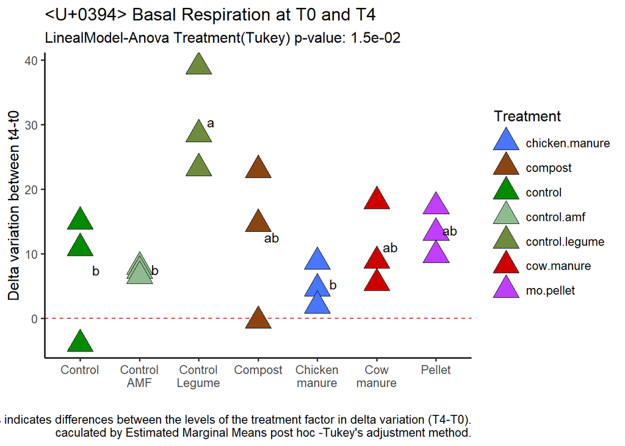

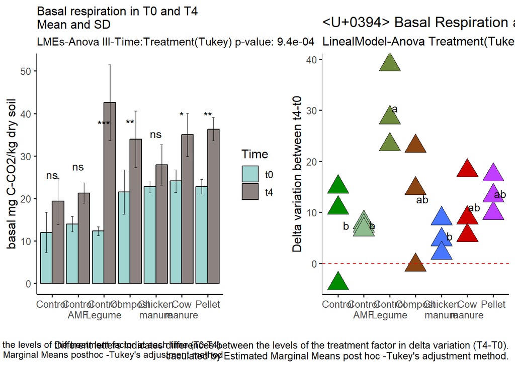

[figure not shown]

```
##
##  Shapiro-Wilk normality test
##
## data:  respirationt0t4$mg_co_induced
## W = 0.88721, p-value = 0.0006096
```

```
## Levene's Test for Homogeneity of Variance (center = median)
##       Df F value Pr(>F)
## group 13  0.6604 0.7826
##       28
```

```
## boundary (singular) fit: see help('isSingular')
```

```
## Linear mixed model fit by REML. t-tests use Satterthwaite's method [
## lmerModLmerTest]
## Formula: mg_co_induced ~ time * treatment + (1 | treat.pot)
##    Data: respirationt0t4
##
## REML criterion at convergence: 280.4
##
## Scaled residuals:
##      Min       1Q   Median       3Q      Max
## -2.61975 -0.49261  0.06333  0.45206  1.58708
##
## Random effects:
##  Groups    Name        Variance Std.Dev.
##  treat.pot (Intercept)   0.0     0.0
##  Residual              756.2    27.5
## Number of obs: 42, groups:  treat.pot, 21
##
## Fixed effects:
##                                Estimate Std. Error      df t value Pr(>|t|)
## (Intercept)                      200.72      15.88   28.00  12.642 4.31e-13 ***
## timet4                          -103.11      22.45   28.00  -4.592 8.45e-05 ***
## treatmentcompost                 -77.29      22.45   28.00  -3.442 0.001831 **
## treatmentcontrol                -102.84      22.45   28.00  -4.580 8.73e-05 ***
## treatmentcontrol.amf            -119.78      22.45   28.00  -5.335 1.11e-05 ***
## treatmentcontrol.legume         -128.08      22.45   28.00  -5.705 4.06e-06 ***
## treatmentcow.manure              -16.92      22.45   28.00  -0.754 0.457407
## treatmentmo.pellet              -115.26      22.45   28.00  -5.133 1.93e-05 ***
## timet4:treatmentcompost           98.47      31.75   28.00   3.101 0.004366 **
## timet4:treatmentcontrol           72.88      31.75   28.00   2.295 0.029417 *
## timet4:treatmentcontrol.amf       96.69      31.75   28.00   3.045 0.005022 **
## timet4:treatmentcontrol.legume   179.50      31.75   28.00   5.653 4.68e-06 ***
## timet4:treatmentcow.manure        49.68      31.75   28.00   1.565 0.128922
## timet4:treatmentmo.pellet        132.96      31.75   28.00   4.187 0.000254 ***
## ---
## Signif. codes:  0 '***' 0.001 '**' 0.01 '*' 0.05 '.' 0.1 ' ' 1
```

```
##
## Correlation matrix not shown by default, as p = 14 > 12.
## Use print(x, correlation=TRUE)  or
##     vcov(x)        if you need it
```

```
## optimizer (nloptwrap) convergence code: 0 (OK)
## boundary (singular) fit: see help('isSingular')
```

```
## Type III Analysis of Variance Table with Satterthwaite's method
##                Sum Sq Mean Sq NumDF DenDF F value    Pr(>F)
## time             1797  1797.2     1    28  2.3766 0.1343950
## treatment       33779  5629.8     6    28  7.4448 7.835e-05 ***
## time:treatment  29986  4997.7     6    28  6.6089 0.0001959 ***
## ---
## Signif. codes:  0 '***' 0.001 '**' 0.01 '*' 0.05 '.' 0.1 ' ' 1
```

```
## $emmeans
## treatment = chicken.manure:
##  time emmean   SE df lower.CL upper.CL
##  t0    200.7 15.9 28    168.2      233
##  t4     97.6 15.9 28     65.1      130
##
## treatment = compost:
##  time emmean   SE df lower.CL upper.CL
##  t0    123.4 15.9 28     90.9      156
##  t4    118.8 15.9 28     86.3      151
##
## treatment = control:
##  time emmean   SE df lower.CL upper.CL
##  t0     97.9 15.9 28     65.4      130
##  t4     67.7 15.9 28     35.1      100
##
## treatment = control.amf:
##  time emmean   SE df lower.CL upper.CL
##  t0     80.9 15.9 28     48.4      113
##  t4     74.5 15.9 28     42.0      107
##
## treatment = control.legume:
##  time emmean   SE df lower.CL upper.CL
##  t0     72.6 15.9 28     40.1      105
##  t4    149.0 15.9 28    116.5      182
##
## treatment = cow.manure:
##  time emmean   SE df lower.CL upper.CL
##  t0    183.8 15.9 28    151.3      216
##  t4    130.4 15.9 28     97.8      163
##
## treatment = mo.pellet:
##  time emmean   SE df lower.CL upper.CL
##  t0     85.5 15.9 28     52.9      118
##  t4    115.3 15.9 28     82.8      148
##
## Degrees-of-freedom method: kenward-roger
## Confidence level used: 0.95
##
## $contrasts
```

[output cut: 14 more lines]

```
##  t0 - t4      6.42 22.5 14   0.286  0.7793
##
## treatment = control.legume:
##  contrast estimate   SE df t.ratio p.value
##  t0 - t4    -76.39 22.5 14  -3.402  0.0043
##
## treatment = cow.manure:
##  contrast estimate   SE df t.ratio p.value
##  t0 - t4     53.43 22.5 14   2.380  0.0321
##
## treatment = mo.pellet:
##  contrast estimate   SE df t.ratio p.value
##  t0 - t4    -29.85 22.5 14  -1.329  0.2050
##
## Degrees-of-freedom method: kenward-roger
```

```
##  treatment      contrast estimate   SE df lower.CL upper.CL t.ratio p.value
##  chicken.manure t0 - t4    103.11 22.5 14     32.5   173.75   4.592  0.0029
##  compost        t0 - t4      4.64 22.5 14    -66.0    75.28   0.206  0.8394
##  control        t0 - t4     30.23 22.5 14    -40.4   100.87   1.346  0.2870
##  control.amf    t0 - t4      6.42 22.5 14    -64.2    77.06   0.286  0.8394
##  control.legume t0 - t4    -76.39 22.5 14   -147.0    -5.74  -3.402  0.0150
##  cow.manure     t0 - t4     53.43 22.5 14    -17.2   124.08   2.380  0.0749
##  mo.pellet      t0 - t4    -29.85 22.5 14   -100.5    40.80  -1.329  0.2870
##
## Degrees-of-freedom method: kenward-roger
## Confidence level used: 0.95
## Conf-level adjustment: bonferroni method for 7 estimates
## P value adjustment: fdr method for 7 tests
```

```
##   contrast      treatment   estimate       SE df    t.ratio      p.value
## 1  t0 - t4 chicken.manure 103.109242 22.45299 14  4.5922269 0.0004186112
## 2  t0 - t4        compost   4.635233 22.45299 14  0.2064416 0.8394181200
## 3  t0 - t4        control  30.226558 22.45299 14  1.3462151 0.1996270759
## 4  t0 - t4    control.amf   6.415730 22.45299 14  0.2857405 0.7792611000
## 5  t0 - t4 control.legume -76.389374 22.45299 14 -3.4021911 0.0042941346
## 6  t0 - t4     cow.manure  53.429617 22.45299 14  2.3796211 0.0320963892
## 7  t0 - t4      mo.pellet -29.847664 22.45299 14 -1.3293401 0.2049925286
```

```
## # A tibble: 7 x 2
##   treatment      emmean
##   <fct>           <dbl>
## 1 chicken.manure  149.
## 2 compost         121.
## 3 control          82.8
## 4 control.amf      77.7
## 5 control.legume  111.
## 6 cow.manure      157.
## 7 mo.pellet       100.
```

```
## NOTE: Results may be misleading due to involvement in interactions
```

```
##  treatment      emmean   SE df lower.CL upper.CL .group
##  cow.manure      157.1 11.2 14    133.0      181  a
##  chicken.manure  149.2 11.2 14    125.1      173  ab
##  compost         121.1 11.2 14     97.0      145  abc
##  control.legume  110.8 11.2 14     86.7      135  abc
##  mo.pellet       100.4 11.2 14     76.3      124   bc
##  control          82.8 11.2 14     58.7      107    c
##  control.amf      77.7 11.2 14     53.7      102    c
##
## Results are averaged over the levels of: time
## Degrees-of-freedom method: kenward-roger
## Confidence level used: 0.95
## P value adjustment: tukey method for comparing a family of 7 estimates
## significance level used: alpha = 0.05
## NOTE: If two or more means share the same grouping symbol,
##       then we cannot show them to be different.
##       But we also did not show them to be the same.
```

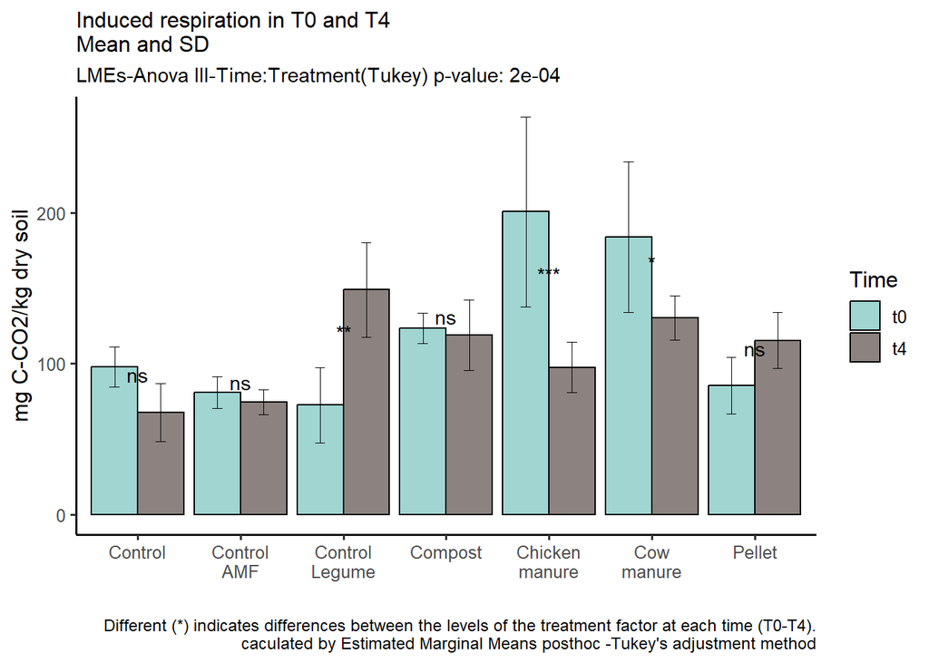

```
##         treatment        t4        t0       delta
## 1         control  45.63053  83.43091  -37.800382
## 2         control  78.85514 100.19084  -21.335700
## 3         control  78.46916 110.01276  -31.543592
## 4     control.amf  78.99113  70.09346    8.897673
## 5     control.amf  79.61783  90.79903  -11.181197
## 6     control.amf  64.95381  81.91748  -16.963665
## 7  chicken.manure  96.69283 128.67647  -31.983645
## 8  chicken.manure  81.33562 229.11471 -147.779097
## 9  chicken.manure 114.79592 244.36090 -129.564984
## 10     cow.manure 133.92857 128.67647    5.252101
## 11     cow.manure 114.27765 225.60160 -111.323952
## 12     cow.manure 142.89838 197.11538  -54.217001
## 13      mo.pellet  94.82759  81.32530   13.502285
## 14      mo.pellet 119.96445  69.27340   50.691056
## 15      mo.pellet 131.11888 105.76923   25.349650
## 16        compost  94.82759 119.04762  -24.220033
## 17        compost 119.96445 134.96144  -14.996985
## 18        compost 141.59039 116.27907   25.311319
## 19 control.legume 183.74165  47.74306  135.998593
## 20 control.legume 140.30612  97.51773   42.788392
## 21 control.legume 123.02036  72.63923   50.381137
```

```
## $emmeans
##  treatment       emmean   SE df lower.CL upper.CL
##  chicken.manure -103.11 23.2 14   -152.8   -53.44
##  compost          -4.64 23.2 14    -54.3    45.03
##  control         -30.23 23.2 14    -79.9    19.44
##  control.amf      -6.42 23.2 14    -56.1    43.25
##  control.legume   76.39 23.2 14     26.7   126.06
##  cow.manure      -53.43 23.2 14   -103.1    -3.76
##  mo.pellet        29.85 23.2 14    -19.8    79.52
##
## Confidence level used: 0.95
##
## $contrasts
##  contrast                        estimate   SE df t.ratio p.value
##  chicken.manure - compost          -98.47 32.8 14  -3.007  0.1018
##  chicken.manure - control          -72.88 32.8 14  -2.225  0.3417
##  chicken.manure - control.amf      -96.69 32.8 14  -2.952  0.1116
##  chicken.manure - control.legume  -179.50 32.8 14  -5.481  0.0012
##  chicken.manure - cow.manure       -49.68 32.8 14  -1.517  0.7315
##  chicken.manure - mo.pellet       -132.96 32.8 14  -4.060  0.0156
##  compost - control                  25.59 32.8 14   0.781  0.9832
##  compost - control.amf               1.78 32.8 14   0.054  1.0000
##  compost - control.legume          -81.02 32.8 14  -2.474  0.2397
##  compost - cow.manure               48.79 32.8 14   1.490  0.7463
##  compost - mo.pellet               -34.48 32.8 14  -1.053  0.9319
##  control - control.amf             -23.81 32.8 14  -0.727  0.9883
##  control - control.legume         -106.62 32.8 14  -3.255  0.0663
##  control - cow.manure               23.20 32.8 14   0.708  0.9898
##  control - mo.pellet               -60.07 32.8 14  -1.834  0.5484
##  control.amf - control.legume      -82.81 32.8 14  -2.528  0.2208
##  control.amf - cow.manure           47.01 32.8 14   1.436  0.7752
##  control.amf - mo.pellet           -36.26 32.8 14  -1.107  0.9157
##  control.legume - cow.manure       129.82 32.8 14   3.964  0.0185
##  control.legume - mo.pellet         46.54 32.8 14   1.421  0.7827
##  cow.manure - mo.pellet            -83.28 32.8 14  -2.543  0.2160
##
## P value adjustment: tukey method for comparing a family of 7 estimates
```

```
##  contrast                        estimate   SE df lower.CL upper.CL t.ratio
##  chicken.manure - compost          -98.47 32.8 14  -219.63     22.7  -3.007
##  chicken.manure - control          -72.88 32.8 14  -194.04     48.3  -2.225
##  chicken.manure - control.amf      -96.69 32.8 14  -217.85     24.5  -2.952
##  chicken.manure - control.legume  -179.50 32.8 14  -300.65    -58.3  -5.481
##  chicken.manure - cow.manure       -49.68 32.8 14  -170.83     71.5  -1.517
##  chicken.manure - mo.pellet       -132.96 32.8 14  -254.11    -11.8  -4.060
##  compost - control                  25.59 32.8 14   -95.56    146.7   0.781
##  compost - control.amf               1.78 32.8 14  -119.37    122.9   0.054
##  compost - control.legume          -81.02 32.8 14  -202.18     40.1  -2.474
##  compost - cow.manure               48.79 32.8 14   -72.36    169.9   1.490
##  compost - mo.pellet               -34.48 32.8 14  -155.64     86.7  -1.053
##  control - control.amf             -23.81 32.8 14  -144.96     97.3  -0.727
##  control - control.legume         -106.62 32.8 14  -227.77     14.5  -3.255
##  control - cow.manure               23.20 32.8 14   -97.95    144.4   0.708
##  control - mo.pellet               -60.07 32.8 14  -181.23     61.1  -1.834
##  control.amf - control.legume      -82.81 32.8 14  -203.96     38.3  -2.528
##  control.amf - cow.manure           47.01 32.8 14   -74.14    168.2   1.436
##  control.amf - mo.pellet           -36.26 32.8 14  -157.42     84.9  -1.107
##  control.legume - cow.manure       129.82 32.8 14     8.67    251.0   3.964
##  control.legume - mo.pellet         46.54 32.8 14   -74.61    167.7   1.421
##  cow.manure - mo.pellet            -83.28 32.8 14  -204.43     37.9  -2.543
##  p.value
##   0.0367
##   0.0903
##   0.0367
##   0.0017
##   0.2481
##   0.0099
##   0.5148
##   0.9574
##   0.0625
##   0.2481
##   0.3832
##   0.5148
##   0.0302
##   0.5148
##   0.1679
##   0.0625
##   0.2481
##   0.3765
##   0.0099
##   0.2481
##   0.0625
##
## Confidence level used: 0.95
## Conf-level adjustment: bonferroni method for 21 estimates
## P value adjustment: fdr method for 21 tests
```

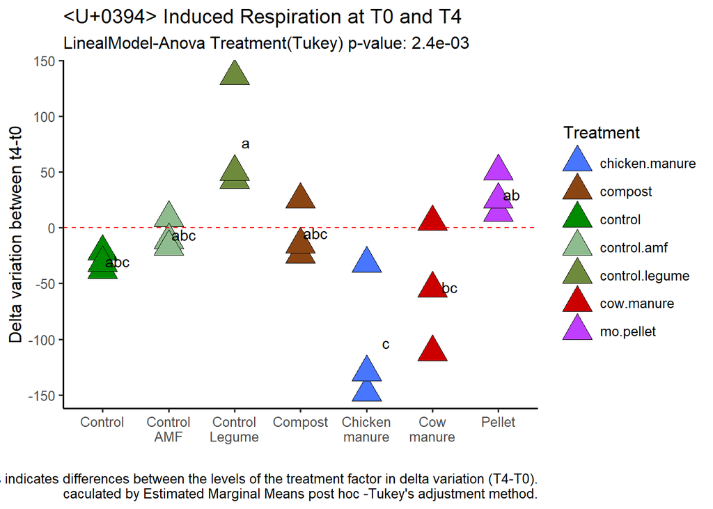

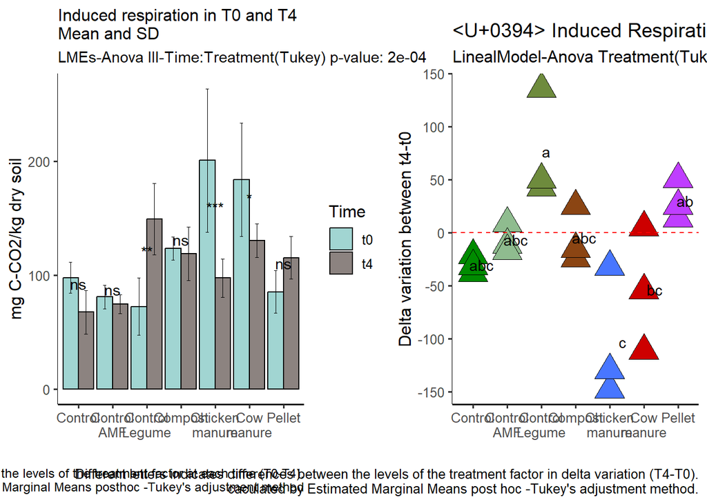

[figure not shown]